# FZJ Data Analysis

## A. Exploration of the timeseries dataframe

Scatter plots by Genotype

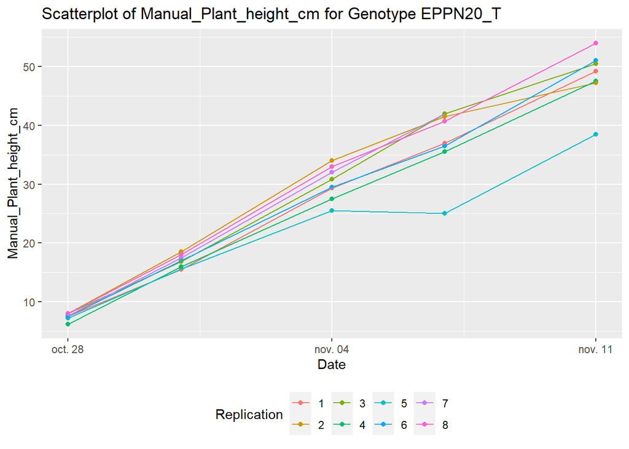

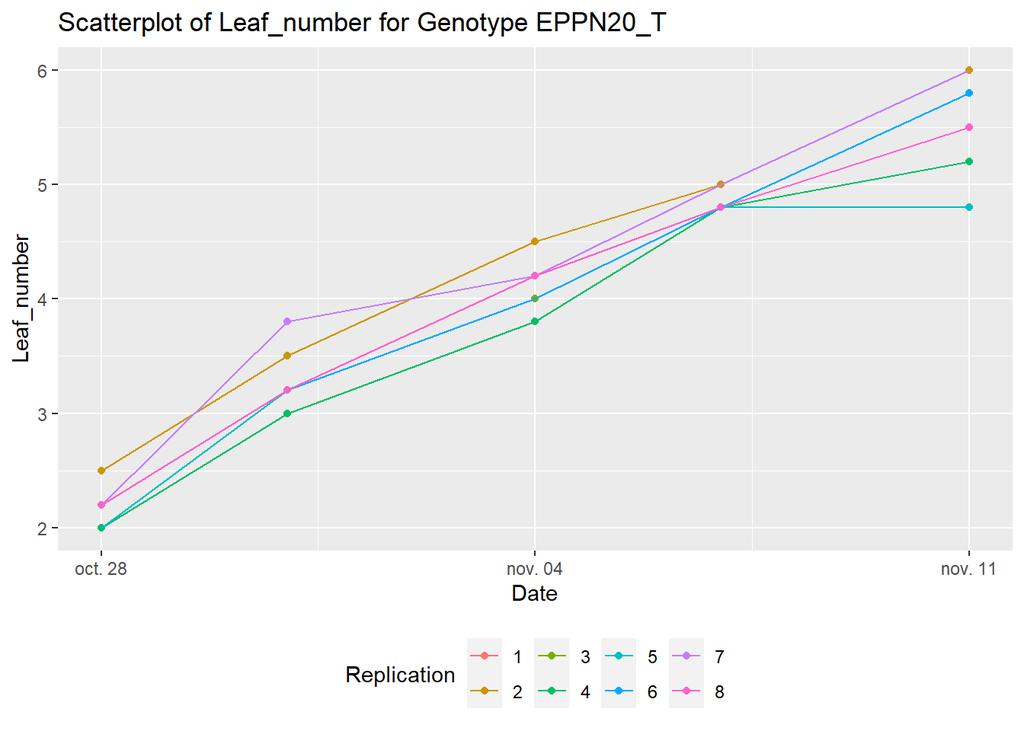

```r
plot_scatter_by_genotype <- function(data, variables, genotype) {
  data_filtered <- data[data$Genotype == genotype, ]

  plots <- list()

  for (var in variables) {
    p <- ggplot(data_filtered, aes_string(x = "Date", y = var, group = "Replication", color = "factor(Replication)")) +
      geom_point() +
      geom_line() +
      labs(title = paste("Scatterplot of", var, "for Genotype", genotype),
           x = "Date", y = var, color = "Replication") +
      theme(legend.position = "bottom")
    plots[[var]] <- p  # Ajouter le graphique à la liste
  }

  return(plots)  # Retourner la liste de graphiques
}
# Appeler la fonction pour chaque variable dans variables_t
for (var in variables_t) {
  plots <- plot_scatter_by_genotype(timeseries, var, "EPPN20_T")
  print(plots)
}
```

Scatterplots for all genotypes by Plant type (Hybride, Line, EPPN20_T) with smooth line.

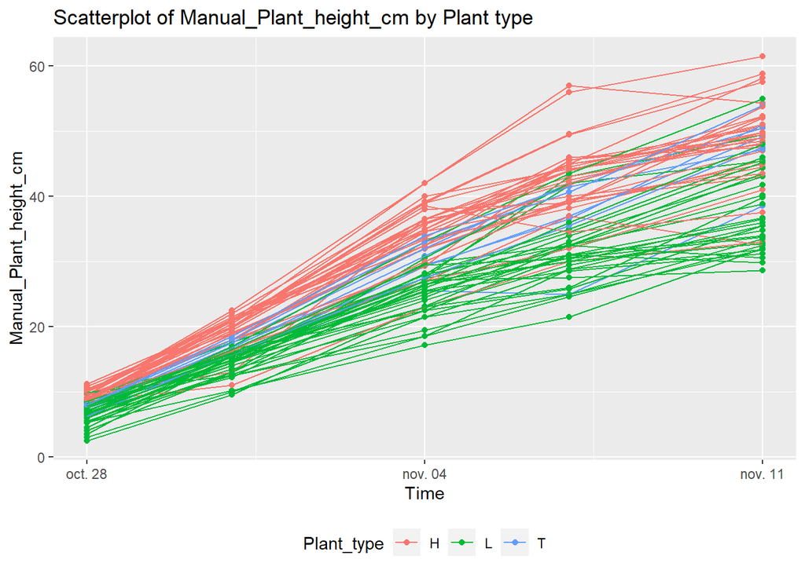

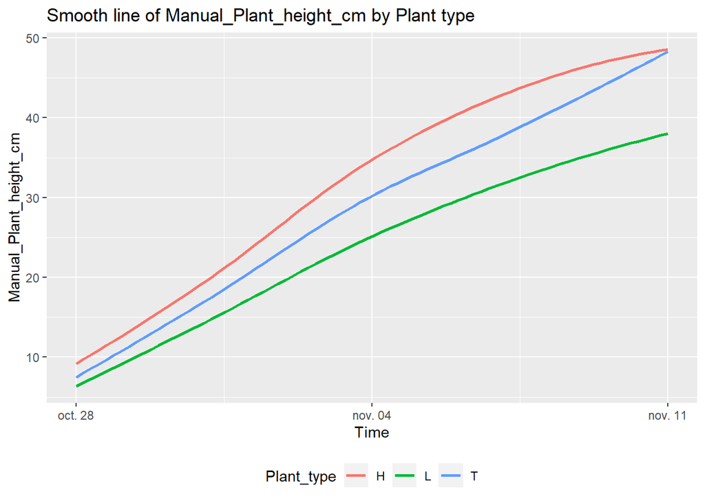

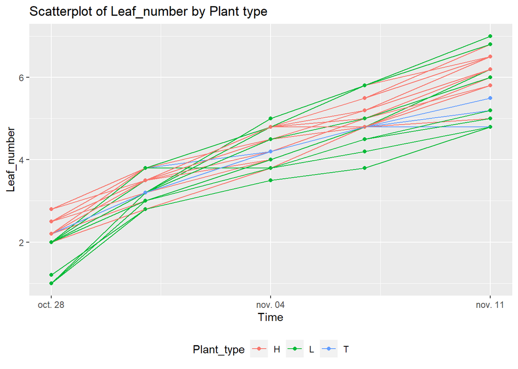

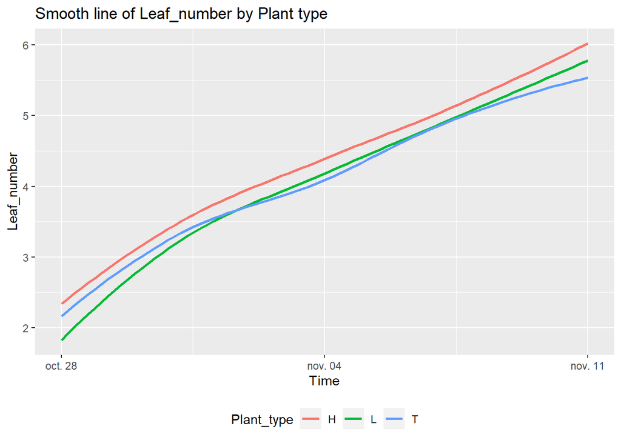

```r
plot_scatter_with_smooth <- function(data, variables) {
  for (var in variables) {
    p1 <- ggplot(data, aes_string(x = "Date", y = var, group = "Unit.ID", color = "factor(Plant_type)")) +
      geom_point() +
      geom_line() +
      labs(title = paste("Scatterplot of", var, "by Plant type"),
           x = "Time", y = var, color = "Plant_type") +
      theme(legend.position = "bottom")

    p2 <- ggplot(data, aes_string(x = "Date", y = var, group = "Plant_type", color = "factor(Plant_type)")) +
      geom_smooth(method = "loess", se = FALSE) +
      labs(title = paste("Smooth line of", var, "by Plant type"),
           x = "Time", y = var, color = "Plant_type") +
      theme(legend.position = "bottom")

    print(p1)
    print(p2)
  }
}

plot_scatter_with_smooth(timeseries, variables_t)
```

Scatter plots for all genotypes by water treatment

```r
print(paste0("No data for", platform))
```

```
## [1] "No data forFZJ"
```

## B. Exploration of the S_timeseries dataframe

Scatter plots by Genotype

```r
print(paste0("No data for", platform))
```

```
## [1] "No data forFZJ"
```

Scatterplots for all genotypes by Plant type (Hybride, Line, EPPN20_T) with smooth line.

```r
print(paste0("No data for", platform))
```

```
## [1] "No data forFZJ"
```

Scatter plots for all genotypes by water treatment

```r
print(paste0("No data for", platform))
```

```
## [1] "No data forFZJ"
```

## C. Exploration of the T_timeseries dataframe

Scatter plots by Genotype

```r
print(paste0("No data for", platform))
```

```
## [1] "No data forFZJ"
```

Scatterplots for all genotypes by Plant type (Hybride, Line, EPPN20_T) with smooth line.

```r
print(paste0("No data for", platform))
```

```
## [1] "No data forFZJ"
```

Scatter plots for all genotypes by water treatment

```r
print(paste0("No data for", platform))
```

```
## [1] "No data forFZJ"
```